# STAT210_FinalProject_VideoGames

Armando Flores

## Introduction

This dataset of video games information covers variables from Name of the video game, gaming Platform, Year_of_Release, type of Genre, Publisher, sales across North America(NA), Japan(JP), Europe(EU), the other regions, and the global sales numbers. In addition, it also includes Critic Scores, number of Critics, User Scores, Number of Users, Game Developer, and Mature Rating.Then, it has the Platform type, User Rating and Critic Rating. After recently turning 20 years old at the beginning of December, I bought a couple games that I have been looking at for awhile. After my purchase, I pondered what have been the trends of game sales across the two decades that I have been alive, so I decided to look at annual sales of specific genres. I collected my raw data from a public github of datasets, at this link “https://raw.githubusercontent.com/prasertcbs/basic-dataset/master/Videogame/videogame_clean.csv”.

## Graphic 1

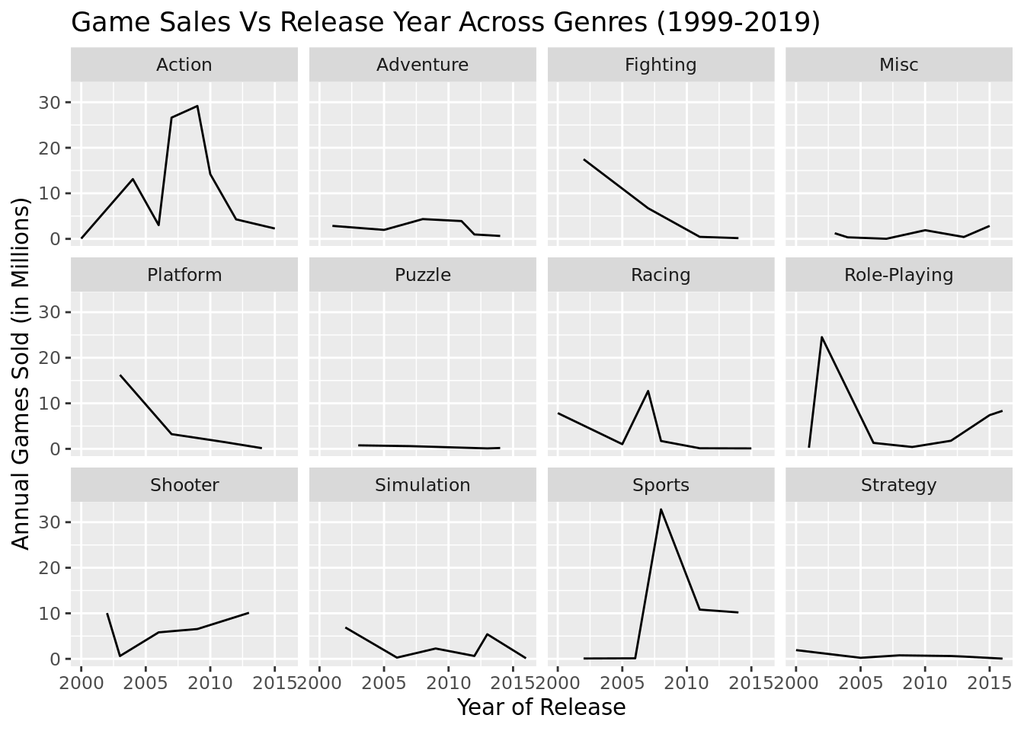